# QTM 151 - Quiz 2

## Try to submit as an HTML file

Print your name below

```python
# Write your answer here
print("Jack Chapon")
```

```
Jack Chapon
```

This quiz is open book

- You can use the lecture notes
- You will get partial credit for attempting the questions
- To get full credit, the code should run as intended
- You should NOT communicate with other students

Print the following message:

"I will abide by Emory's code of conduct"

```python
# Write your answer here:
print("I will abide by Emory's code of conduct")
```

```
I will abide by Emory's code of conduct
```

Import the libraries "numpy", "matplotlib.pyplot",  
"pandas", "statsmodels.api" and "statsmodels.formula.api"

```python
# Write your answer here
import numpy as np
import matplotlib.pyplot as plt
import statsmodels.api as sm
import statsmodels.formula.api as smf
```

Read the dataset "data_quiz/fifa23_players_basic.csv"

- It's a dataset on professional soccer players
- Rows correspond to players (18,539)
- Columns contain attributes of players (32)
- Try to view the dataset before starting

to get a sense of its content

```python
# Write your own code
fifa = pd.read_csv("data_quiz/fifa23_players_basic.csv")
fifa
```

|  | Unnamed: 0 | Known As | Full Name | Overall | Potential | Value(in Euro) | Positions Played | Best Position | Nationality | Image Link | ... | Preferred Foot | Weak Foot Rating | Skill Moves | International Reputation | National Team Name | National Team Image Link | National Team Position | National Team Jersey Number | Attacking Work Rate | Defensive Work Rate |
| --- | --- | --- | --- | --- | --- | --- | --- | --- | --- | --- | --- | --- | --- | --- | --- | --- | --- | --- | --- | --- | --- |
| 0 | 0 | L. Messi | Lionel Messi | 91 | 91 | 54000000 | RW | CAM | Argentina | https://cdn.sofifa.net/players/158/023/23_60.png | ... | Left | 4 | 4 | 5 | Argentina | https://cdn.sofifa.net/flags/ar.png | RW | 10 | Low | Low |
| 1 | 1 | K. Benzema | Karim Benzema | 91 | 91 | 64000000 | CF,ST | CF | France | https://cdn.sofifa.net/players/165/153/23_60.png | ... | Right | 4 | 4 | 4 | France | https://cdn.sofifa.net/flags/fr.png | ST | 19 | Medium | Medium |
| 2 | 2 | R. Lewandowski | Robert Lewandowski | 91 | 91 | 84000000 | ST | ST | Poland | https://cdn.sofifa.net/players/188/545/23_60.png | ... | Right | 4 | 4 | 5 | Poland | https://cdn.sofifa.net/flags/pl.png | ST | 9 | High | Medium |
| 3 | 3 | K. De Bruyne | Kevin De Bruyne | 91 | 91 | 107500000 | CM,CAM | CM | Belgium | https://cdn.sofifa.net/players/192/985/23_60.png | ... | Right | 5 | 4 | 4 | Belgium | https://cdn.sofifa.net/flags/be.png | RF | 7 | High | High |
| 4 | 4 | K. Mbappé | Kylian Mbappé | 91 | 95 | 190500000 | ST,LW | ST | France | https://cdn.sofifa.net/players/231/747/23_60.png | ... | Right | 4 | 5 | 4 | France | https://cdn.sofifa.net/flags/fr.png | ST | 10 | High | Low |
| ... | ... | ... | ... | ... | ... | ... | ... | ... | ... | ... | ... | ... | ... | ... | ... | ... | ... | ... | ... | ... | ... |
| 18534 | 18534 | D. Collins | Darren Collins | 47 | 56 | 110000 | ST,RM | CAM | Republic of Ireland | https://cdn.sofifa.net/players/243/725/23_60.png | ... | Right | 3 | 2 | 1 | - | - | - | - | Medium | Medium |
| 18535 | 18535 | Yang Dejiang | Dejiang Yang | 47 | 57 | 90000 | CDM | CDM | China PR | https://cdn.sofifa.net/players/261/933/23_60.png | ... | Right | 3 | 2 | 1 | - | - | - | - | Medium | Medium |
| 18536 | 18536 | L. Mullan | Liam Mullan | 47 | 67 | 130000 | CM | RM | Northern Ireland | https://cdn.sofifa.net/players/267/823/23_60.png | ... | Right | 3 | 2 | 1 | - | - | - | - | High | Medium |
| 18537 | 18537 | D. McCallion | Daithí McCallion | 47 | 61 | 100000 | CB | CB | Republic of Ireland | https://cdn.sofifa.net/players/267/824/23_60.png | ... | Right | 3 | 2 | 1 | - | - | - | - | Medium | Medium |
| 18538 | 18538 | N. Rabha | Nabin Rabha | 47 | 50 | 60000 | LB | LB | India | https://cdn.sofifa.net/players/261/424/23_60.png | ... | Left | 3 | 2 | 1 | - | - | - | - | Medium | Medium |

18539 rows × 33 columns

(a) Use queries

- Browse the dataset and search for the height variable in cm (centimeters).
- Subset the players whose value of the height variable is above 175

and store it in a new dataset

- How many players are above this height threshold?

HINT: Remember that there is a special syntax for  
when the column names have spaces (see Lecture 10)  
and when the value is a string. See example provided.

```python
# Write your own code

# Example: The following code filters whether
# observations for which `On Loan` is equal to yes
# dataset.query(' `On Loan` == "YES" ')
# Note: be careful with using backward quotations ` here.
# Now apply this to your own example, and calculate the total number of observations.
tall = fifa.query('`Height(in cm)` > 175')
display(tall)
print(len(tall))
```

|  | Unnamed: 0 | Known As | Full Name | Overall | Potential | Value(in Euro) | Positions Played | Best Position | Nationality | Image Link | ... | Preferred Foot | Weak Foot Rating | Skill Moves | International Reputation | National Team Name | National Team Image Link | National Team Position | National Team Jersey Number | Attacking Work Rate | Defensive Work Rate |
| --- | --- | --- | --- | --- | --- | --- | --- | --- | --- | --- | --- | --- | --- | --- | --- | --- | --- | --- | --- | --- | --- |
| 1 | 1 | K. Benzema | Karim Benzema | 91 | 91 | 64000000 | CF,ST | CF | France | https://cdn.sofifa.net/players/165/153/23_60.png | ... | Right | 4 | 4 | 4 | France | https://cdn.sofifa.net/flags/fr.png | ST | 19 | Medium | Medium |
| 2 | 2 | R. Lewandowski | Robert Lewandowski | 91 | 91 | 84000000 | ST | ST | Poland | https://cdn.sofifa.net/players/188/545/23_60.png | ... | Right | 4 | 4 | 5 | Poland | https://cdn.sofifa.net/flags/pl.png | ST | 9 | High | Medium |
| 3 | 3 | K. De Bruyne | Kevin De Bruyne | 91 | 91 | 107500000 | CM,CAM | CM | Belgium | https://cdn.sofifa.net/players/192/985/23_60.png | ... | Right | 5 | 4 | 4 | Belgium | https://cdn.sofifa.net/flags/be.png | RF | 7 | High | High |
| 4 | 4 | K. Mbappé | Kylian Mbappé | 91 | 95 | 190500000 | ST,LW | ST | France | https://cdn.sofifa.net/players/231/747/23_60.png | ... | Right | 4 | 5 | 4 | France | https://cdn.sofifa.net/flags/fr.png | ST | 10 | High | Low |
| 6 | 6 | T. Courtois | Thibaut Courtois | 90 | 91 | 90000000 | GK | GK | Belgium | https://cdn.sofifa.net/players/192/119/23_60.png | ... | Left | 3 | 1 | 4 | Belgium | https://cdn.sofifa.net/flags/be.png | GK | 1 | Medium | Medium |
| ... | ... | ... | ... | ... | ... | ... | ... | ... | ... | ... | ... | ... | ... | ... | ... | ... | ... | ... | ... | ... | ... |
| 18530 | 18530 | S. Bag | Sajal Bag | 48 | 61 | 110000 | CM,RM | RM | India | https://cdn.sofifa.net/players/270/739/23_60.png | ... | Right | 4 | 2 | 1 | - | - | - | - | Medium | Medium |
| 18531 | 18531 | Liao Wei | Wei Liao | 48 | 54 | 70000 | RM,LM | CDM | China PR | https://cdn.sofifa.net/players/257/691/23_60.png | ... | Right | 3 | 2 | 1 | - | - | - | - | Medium | Medium |
| 18532 | 18532 | H. Singh | Harmanpreet Singh | 48 | 56 | 100000 | ST | ST | India | https://cdn.sofifa.net/players/259/745/23_60.png | ... | Right | 2 | 2 | 1 | - | - | - | - | Medium | Low |
| 18537 | 18537 | D. McCallion | Daithí McCallion | 47 | 61 | 100000 | CB | CB | Republic of Ireland | https://cdn.sofifa.net/players/267/824/23_60.png | ... | Right | 3 | 2 | 1 | - | - | - | - | Medium | Medium |
| 18538 | 18538 | N. Rabha | Nabin Rabha | 47 | 50 | 60000 | LB | LB | India | https://cdn.sofifa.net/players/261/424/23_60.png | ... | Left | 3 | 2 | 1 | - | - | - | - | Medium | Medium |

14653 rows × 33 columns

```
14653
```

(b) Use sorting + ".iloc[]"

The varable "Contract Until" shows the date in which a player's contract will expire.

- Use ".sort_values()" to order the "Contract Until" column

from later dates to earlier dates.

whose contracts will expire later.

- From this subset, display the names and year in which the contract will expire.

Your output should look something like this:

| Full Name | Contract Until |
| --- | --- |
| José Luis García Vayá | 2032 |
| José Luis García Vayá | 2032 |
| Jon Moncayola Tollar | 2031 |
| Jon Moncayloa Tollar | 2031 |
| Josip Sutalo | 2028 |
| Aurelien Tchouaméni | 2028 |

```python
# Write your own code
contractsort = fifa.sort_values(by = "Contract Until", ascending = False)
display(contractsort)
sorted = contractsort.iloc[0:6][["Full Name", "Contract Until"]]
sorted
```

|  | Unnamed: 0 | Known As | Full Name | Overall | Potential | Value(in Euro) | Positions Played | Best Position | Nationality | Image Link | ... | Preferred Foot | Weak Foot Rating | Skill Moves | International Reputation | National Team Name | National Team Image Link | National Team Position | National Team Jersey Number | Attacking Work Rate | Defensive Work Rate |
| --- | --- | --- | --- | --- | --- | --- | --- | --- | --- | --- | --- | --- | --- | --- | --- | --- | --- | --- | --- | --- | --- |
| 1876 | 1876 | Pepelu | Jose Luís García Vayá | 75 | 81 | 9000000 | CM,CDM | CM | Spain | https://cdn.sofifa.net/players/230/786/23_60.png | ... | Right | 3 | 3 | 1 | - | https://cdn.sofifa.net/flags/es.png | - | - | Medium | Medium |
| 1806 | 1806 | Pepelu | Jose Luís García Vayá | 75 | 81 | 9000000 | CM,CDM | CM | Spain | https://cdn.sofifa.net/players/230/786/23_60.png | ... | Right | 3 | 3 | 1 | - | https://cdn.sofifa.net/flags/es.png | - | - | Medium | Medium |
| 1478 | 1478 | Moncayola | Jon Moncayola Tollar | 75 | 81 | 9000000 | CM,CDM | CM | Spain | https://cdn.sofifa.net/players/247/495/23_60.png | ... | Right | 4 | 3 | 1 | - | https://cdn.sofifa.net/flags/es.png | - | - | Medium | High |
| 1523 | 1523 | Moncayola | Jon Moncayola Tollar | 75 | 81 | 9000000 | CM,CDM | CM | Spain | https://cdn.sofifa.net/players/247/495/23_60.png | ... | Right | 4 | 3 | 1 | - | https://cdn.sofifa.net/flags/es.png | - | - | Medium | High |
| 1649 | 1649 | J. Šutalo | Josip Šutalo | 75 | 84 | 12000000 | CB | CB | Croatia | https://cdn.sofifa.net/players/256/325/23_60.png | ... | Right | 3 | 2 | 1 | Croatia | https://cdn.sofifa.net/flags/hr.png | SUB | 5 | Medium | High |
| ... | ... | ... | ... | ... | ... | ... | ... | ... | ... | ... | ... | ... | ... | ... | ... | ... | ... | ... | ... | ... | ... |
| 9943 | 9943 | M. Kheder | Musab Kheder | 65 | 65 | 0 | RWB,CB | RWB | Qatar | https://cdn.sofifa.net/players/268/784/23_60.png | ... | Right | 3 | 2 | 1 | Qatar | https://cdn.sofifa.net/flags/qa.png | SUB | 13 | Medium | Medium |
| 3505 | 3505 | K. Boudiaf | Karim Boudiaf | 72 | 72 | 0 | CM,CDM | CM | Qatar | https://cdn.sofifa.net/players/268/778/23_60.png | ... | Right | 3 | 3 | 1 | Qatar | https://cdn.sofifa.net/flags/qa.png | CM | 12 | Medium | Medium |
| 4961 | 4961 | Á. Lang | Ádám Lang | 70 | 70 | 0 | CB | CB | Hungary | https://cdn.sofifa.net/players/223/207/23_60.png | ... | Right | 3 | 2 | 1 | Hungary | https://cdn.sofifa.net/flags/hu.png | CB | 2 | Medium | Medium |
| 8254 | 8254 | I. Mohammad | Ismael Mohammad | 67 | 67 | 0 | RWB,RW | RWB | Qatar | https://cdn.sofifa.net/players/268/774/23_60.png | ... | Right | 3 | 3 | 1 | Qatar | https://cdn.sofifa.net/flags/qa.png | SUB | 17 | Medium | Low |
| 1901 | 1901 | J. Gallardo | Jesús Gallardo | 75 | 75 | 0 | LB,LM,LW | LB | Mexico | https://cdn.sofifa.net/players/226/045/23_60.png | ... | Left | 3 | 3 | 1 | Mexico | https://cdn.sofifa.net/flags/mx.png | LB | 23 | High | Low |

18539 rows × 33 columns

|  | Full Name | Contract Until |
| --- | --- | --- |
| 1876 | Jose Luís García Vayá | 2032 |
| 1806 | Jose Luís García Vayá | 2032 |
| 1478 | Jon Moncayola Tollar | 2031 |
| 1523 | Jon Moncayola Tollar | 2031 |
| 1649 | Josip Šutalo | 2028 |
| 231 | Aurélien Tchouaméni | 2028 |

(c) Create a function and apply it to a column

Step 1:

- Define a function with a parameter "TotalStats"
- If "TotalStats > 85", classification = "Top Performer"
- If "TotalStats <= 85", classification = "Non Top-Performer"
- The function returns "classification"

Step 2:

- Extract the column "TotalStats" in the dataset
- Create a new variable called "player_classification"

to assign each player to the correct classification

HINT: Use the ".apply()" function

```python
# Write your own code
def fn_stats(TotalStats):
    if TotalStats > 85:
        classification = "Top Performer"
    else:
        classification = "Non Top-Performer"
    return classification

fifa["player_classification"] = fifa["TotalStats"].apply(fn_stats)
display(fifa)
print(fifa["player_classification"])
```

[output not shown]

18539 rows × 35 columns

```
0        Top Performer
1        Top Performer
2        Top Performer
3        Top Performer
4        Top Performer
             ...
18534    Top Performer
18535    Top Performer
18536    Top Performer
18537    Top Performer
18538    Top Performer
Name: player_classification, Length: 18539, dtype: object
```

(d) Regression function

- Run a regression of "Overall" (left-hand side) on "Age" (right-hand side)
- What are the values of the coefficients?

[HINT: Use the commands `smf.ols()` and `.fit()` and `.params`  
from Lecture 11 ]

```python
# Write your own code
regression = smf.ols(formula = 'Overall ~ Age', data = fifa)
results = model.fit()

values = results.params
print(values)
```

[output not shown]

(e) Split a dataset into subsets

- Store the total number of rows of the dataset in a variable called `n`
- Create a new variable called `random_var` drawn from a

uniform distribution between 0 and 1 with size `n`

- Use .query() to subset all observations with `random_var <0.4`.

store it in a new dataset called "data0"

- Use .query() to subset all observations with `random_var >= 0.4`.

store it in a new dataset called "data1"

[HINT: See Lecture 2 for how to generate a uniform random variable]

```python
# Write your own code
n = len(fifa)
fifa["random_var"] = np.random.uniform(low = 0, high = 1, size = n)
data0 = fifa.query('random_var < 0.4')
data1 = fifa.query('random_var >= 0.4')
display(data0)
display(data1)
```

|  | Unnamed: 0 | Known As | Full Name | Overall | Potential | Value(in Euro) | Positions Played | Best Position | Nationality | Image Link | ... | Skill Moves | International Reputation | National Team Name | National Team Image Link | National Team Position | National Team Jersey Number | Attacking Work Rate | Defensive Work Rate | random_var | player_classification |
| --- | --- | --- | --- | --- | --- | --- | --- | --- | --- | --- | --- | --- | --- | --- | --- | --- | --- | --- | --- | --- | --- |
| 12 | 12 | H. Son | Heung Min Son | 89 | 89 | 101000000 | LW,LM | LW | Korea Republic | https://cdn.sofifa.net/players/200/104/23_60.png | ... | 4 | 4 | - | - | - | - | High | Medium | 0.177774 | Top Performer |
| 13 | 13 | Casemiro | Carlos Henrique Venancio Casimiro | 89 | 89 | 86000000 | CDM | CDM | Brazil | https://cdn.sofifa.net/players/200/145/23_60.png | ... | 2 | 3 | - | https://cdn.sofifa.net/flags/br.png | - | - | Medium | High | 0.159291 | Top Performer |
| 15 | 15 | S. Mané | Sadio Mané | 89 | 89 | 99500000 | LM,CF | LM | Senegal | https://cdn.sofifa.net/players/208/722/23_60.png | ... | 4 | 4 | - | - | - | - | High | Medium | 0.046151 | Top Performer |
| 18 | 18 | Alisson | Alisson Ramses Becker | 89 | 90 | 79000000 | GK | GK | Brazil | https://cdn.sofifa.net/players/212/831/23_60.png | ... | 1 | 3 | - | https://cdn.sofifa.net/flags/br.png | - | - | Medium | Medium | 0.176867 | Top Performer |
| 19 | 19 | N. Kanté | N'Golo Kanté | 89 | 89 | 72000000 | CDM,CM | CDM | France | https://cdn.sofifa.net/players/215/914/23_60.png | ... | 2 | 4 | France | https://cdn.sofifa.net/flags/fr.png | CDM | 13 | Medium | High | 0.252393 | Top Performer |
| ... | ... | ... | ... | ... | ... | ... | ... | ... | ... | ... | ... | ... | ... | ... | ... | ... | ... | ... | ... | ... | ... |
| 18512 | 18512 | Li Peinan | Peinan Li | 48 | 56 | 100000 | CB | CB | China PR | https://cdn.sofifa.net/players/268/969/23_60.png | ... | 2 | 1 | - | - | - | - | Medium | Medium | 0.220439 | Top Performer |
| 18519 | 18519 | T. Giraldo | Tomas Giraldo | 48 | 64 | 120000 | CM | CAM | Canada | https://cdn.sofifa.net/players/260/393/23_60.png | ... | 2 | 1 | - | https://cdn.sofifa.net/flags/ca.png | - | - | Medium | Medium | 0.105425 | Top Performer |
| 18522 | 18522 | E. Singh | Engson Singh | 48 | 63 | 110000 | CAM,CM | CAM | India | https://cdn.sofifa.net/players/259/649/23_60.png | ... | 2 | 1 | - | - | - | - | Medium | Low | 0.247566 | Top Performer |
| 18524 | 18524 | A. Brînzea | Andreș Brînzea | 48 | 72 | 130000 | GK | GK | Romania | https://cdn.sofifa.net/players/271/179/23_60.png | ... | 1 | 1 | - | https://cdn.sofifa.net/flags/ro.png | - | - | Medium | Medium | 0.380871 | Top Performer |
| 18526 | 18526 | Chen Chunxin | Chunxin Chen | 48 | 52 | 70000 | CM | RM | China PR | https://cdn.sofifa.net/players/255/597/23_60.png | ... | 2 | 1 | - | - | - | - | Medium | Medium | 0.007500 | Top Performer |

7347 rows × 35 columns

|  | Unnamed: 0 | Known As | Full Name | Overall | Potential | Value(in Euro) | Positions Played | Best Position | Nationality | Image Link | ... | Skill Moves | International Reputation | National Team Name | National Team Image Link | National Team Position | National Team Jersey Number | Attacking Work Rate | Defensive Work Rate | random_var | player_classification |
| --- | --- | --- | --- | --- | --- | --- | --- | --- | --- | --- | --- | --- | --- | --- | --- | --- | --- | --- | --- | --- | --- |
| 0 | 0 | L. Messi | Lionel Messi | 91 | 91 | 54000000 | RW | CAM | Argentina | https://cdn.sofifa.net/players/158/023/23_60.png | ... | 4 | 5 | Argentina | https://cdn.sofifa.net/flags/ar.png | RW | 10 | Low | Low | 0.873788 | Top Performer |
| 1 | 1 | K. Benzema | Karim Benzema | 91 | 91 | 64000000 | CF,ST | CF | France | https://cdn.sofifa.net/players/165/153/23_60.png | ... | 4 | 4 | France | https://cdn.sofifa.net/flags/fr.png | ST | 19 | Medium | Medium | 0.873537 | Top Performer |
| 2 | 2 | R. Lewandowski | Robert Lewandowski | 91 | 91 | 84000000 | ST | ST | Poland | https://cdn.sofifa.net/players/188/545/23_60.png | ... | 4 | 5 | Poland | https://cdn.sofifa.net/flags/pl.png | ST | 9 | High | Medium | 0.465583 | Top Performer |
| 3 | 3 | K. De Bruyne | Kevin De Bruyne | 91 | 91 | 107500000 | CM,CAM | CM | Belgium | https://cdn.sofifa.net/players/192/985/23_60.png | ... | 4 | 4 | Belgium | https://cdn.sofifa.net/flags/be.png | RF | 7 | High | High | 0.783508 | Top Performer |
| 4 | 4 | K. Mbappé | Kylian Mbappé | 91 | 95 | 190500000 | ST,LW | ST | France | https://cdn.sofifa.net/players/231/747/23_60.png | ... | 5 | 4 | France | https://cdn.sofifa.net/flags/fr.png | ST | 10 | High | Low | 0.967540 | Top Performer |
| ... | ... | ... | ... | ... | ... | ... | ... | ... | ... | ... | ... | ... | ... | ... | ... | ... | ... | ... | ... | ... | ... |
| 18534 | 18534 | D. Collins | Darren Collins | 47 | 56 | 110000 | ST,RM | CAM | Republic of Ireland | https://cdn.sofifa.net/players/243/725/23_60.png | ... | 2 | 1 | - | - | - | - | Medium | Medium | 0.623440 | Top Performer |
| 18535 | 18535 | Yang Dejiang | Dejiang Yang | 47 | 57 | 90000 | CDM | CDM | China PR | https://cdn.sofifa.net/players/261/933/23_60.png | ... | 2 | 1 | - | - | - | - | Medium | Medium | 0.988571 | Top Performer |
| 18536 | 18536 | L. Mullan | Liam Mullan | 47 | 67 | 130000 | CM | RM | Northern Ireland | https://cdn.sofifa.net/players/267/823/23_60.png | ... | 2 | 1 | - | - | - | - | High | Medium | 0.416502 | Top Performer |
| 18537 | 18537 | D. McCallion | Daithí McCallion | 47 | 61 | 100000 | CB | CB | Republic of Ireland | https://cdn.sofifa.net/players/267/824/23_60.png | ... | 2 | 1 | - | - | - | - | Medium | Medium | 0.629858 | Top Performer |
| 18538 | 18538 | N. Rabha | Nabin Rabha | 47 | 50 | 60000 | LB | LB | India | https://cdn.sofifa.net/players/261/424/23_60.png | ... | 2 | 1 | - | - | - | - | Medium | Medium | 0.644220 | Top Performer |

11192 rows × 35 columns

(f) Create two overlapping scatter plots

- This question requires the two datasets you created in (e)
- Display a scatter plot of "Potential" vs "Age" for "data0" using

`plt.scatter()`

- Display a scatter plot of "Potential" vs "Age" for "data1" overlapping

on top of the previous one

- You will need to add a legend, label the axes, and the title
- To get full points, plot the scatter plot with the option `alpha = 0.5`, e.g.

`plt.hist(x = ..., y = ... , alpha = 0.5)`  
Make sure to substitute the corresponding "x" and "y" vectors instead of `...`  
(The alpha option sets the transparency of the scatter plot)

Note: The goal of this question is to illustrate that random  
assignment will produce very similar scatter plots for each variable

|  | Unnamed: 0 | Known As | Full Name | Overall | Potential | Value(in Euro) | Positions Played | Best Position | Nationality | Image Link | ... | Skill Moves | International Reputation | National Team Name | National Team Image Link | National Team Position | National Team Jersey Number | Attacking Work Rate | Defensive Work Rate | random_var | player_classification |
| --- | --- | --- | --- | --- | --- | --- | --- | --- | --- | --- | --- | --- | --- | --- | --- | --- | --- | --- | --- | --- | --- |
| 592 | 592 | G. Buffon | Gianluigi Buffon | 79 | 79 | 1900000 | GK | GK | Italy | https://cdn.sofifa.net/players/001/179/23_60.png | ... | 1 | 4 | - | https://cdn.sofifa.net/flags/it.png | - | - | Medium | Medium | 0.979505 | Top Performer |
| 13548 | 13548 | S. Lukić | Stojan Lukić | 62 | 62 | 45000 | GK | GK | Bosnia and Herzegovina | https://cdn.sofifa.net/players/213/483/23_60.png | ... | 1 | 1 | - | - | - | - | Medium | Medium | 0.212449 | Top Performer |
| 3276 | 3276 | S. Torrico | Sebastián Torrico | 72 | 72 | 250000 | GK | GK | Argentina | https://cdn.sofifa.net/players/216/692/23_60.png | ... | 1 | 1 | - | https://cdn.sofifa.net/flags/ar.png | - | - | Medium | Medium | 0.018515 | Top Performer |
| 15525 | 15525 | J. Szmatuła | Jakub Szmatuła | 59 | 59 | 25000 | GK | GK | Poland | https://cdn.sofifa.net/players/155/422/23_60.png | ... | 1 | 1 | - | https://cdn.sofifa.net/flags/pl.png | - | - | Medium | Medium | 0.047157 | Top Performer |
| 10851 | 10851 | M. Galezo | Moisés Galezo | 64 | 64 | 0 | CB | CB | Venezuela | https://cdn.sofifa.net/players/265/721/23_60.png | ... | 2 | 1 | - | https://cdn.sofifa.net/flags/ve.png | - | - | Medium | High | 0.772896 | Top Performer |
| ... | ... | ... | ... | ... | ... | ... | ... | ... | ... | ... | ... | ... | ... | ... | ... | ... | ... | ... | ... | ... | ... |
| 18188 | 18188 | A. Andresen | Aske Andresen | 52 | 73 | 230000 | GK | GK | Denmark | https://cdn.sofifa.net/players/265/179/23_60.png | ... | 1 | 1 | - | https://cdn.sofifa.net/flags/dk.png | - | - | Medium | Medium | 0.010851 | Top Performer |
| 18365 | 18365 | T. Kristiansen | Thorbjørn Kristiansen | 50 | 72 | 140000 | CB | CB | Norway | https://cdn.sofifa.net/players/267/732/23_60.png | ... | 2 | 1 | - | https://cdn.sofifa.net/flags/no.png | - | - | Medium | Medium | 0.685805 | Top Performer |
| 16813 | 16813 | O. Megeed | Omar Megeed | 57 | 77 | 450000 | LW,CAM | RM | Egypt | https://cdn.sofifa.net/players/271/214/23_60.png | ... | 3 | 1 | - | - | - | - | Medium | Medium | 0.518361 | Top Performer |
| 14439 | 14439 | W. Amey | Wisdom Amey | 61 | 81 | 850000 | CB | CB | Italy | https://cdn.sofifa.net/players/269/183/23_60.png | ... | 2 | 1 | - | https://cdn.sofifa.net/flags/it.png | - | - | Medium | Medium | 0.912750 | Top Performer |
| 17193 | 17193 | E. Koyuncu | Efe Arda Koyuncu | 56 | 75 | 325000 | CB | CB | Turkey | https://cdn.sofifa.net/players/268/906/23_60.png | ... | 2 | 1 | - | https://cdn.sofifa.net/flags/tr.png | - | - | Medium | Medium | 0.282617 | Top Performer |

18539 rows × 35 columns

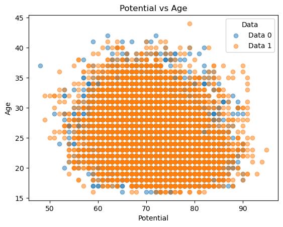

```python
# Write your own code
display(fifa.sort_values(by = "Age", ascending = False))


plt.scatter(x = data0["Potential"], y = data0["Age"], alpha = 0.5)
plt.scatter(x = data1["Potential"], y = data1["Age"], alpha = 0.5)
plt.legend(labels = ["Data 0", "Data 1"], title  = "Data")
plt.xlabel("Potential")
plt.ylabel("Age")
plt.title("Potential vs Age")
```